# Online News Popularity Analysis

Rina Deka and Jessica Ayers

2023-06-29

```r
library(tidyverse)
library(rmarkdown)
library(caret)
```

```r
library(corrplot)
library(gbm)
library(randomForest)
```

# Introduction

**RINA**

*You should have an introduction section that briefly describes the data and the variables you have to work with (just discuss the ones you want to use). Your target variables is the shares variable.*

*You should also mention the purpose of your analysis and the methods you’ll use to model the response. You’ll describe those in more detail later.*

# Data

**RINA or JESS**

*Use a relative path to import the data. Subset the data to work on the data channel of interest.*

```r
#import data set
#my data set is stored in the folder above where I have the project 2 folder
onpdata <- read_csv("../OnlineNewsPopularity/OnlineNewsPopularity.csv")
#create new variable to represent type of channel to use as parameters
for(i in 1:nrow(onpdata)){
  if(onpdata$data_channel_is_lifestyle[i] == 1){
    onpdata$channel[i] <- "Lifestyle"
  }
  else if(onpdata$data_channel_is_entertainment[i] == 1){
    onpdata$channel[i] <- "Entertainment"
  }
  else if(onpdata$data_channel_is_bus[i] == 1){
    onpdata$channel[i] <- "Bus"
  }
  else if(onpdata$data_channel_is_socmed[i] == 1){
    onpdata$channel[i] <- "Socmed"
  }
  else if(onpdata$data_channel_is_tech[i] == 1){
    onpdata$channel[i] <- "Tech"
  }
  else if(onpdata$data_channel_is_world[i] == 1){
    onpdata$channel[i] <- "World"
  }
}
```

```r
channelIDs <- unique(onpdata$channel)
output_file <- paste0(channelIDs, "Analysis.md")
params <- lapply(channelIDs, FUN = function(x){list(channel=x)})
analysis <- tibble(output_file, params)
```

```r
apply(analysis, MARGIN = 1, FUN = function(x){
  render(input = "WorldAnalysis.Rmd", output_file = x[[1]], params = x[[2]])
})
```

```r
onpdata_subset <- subset(onpdata, channel == params[[2]])
unique(onpdata_subset$channel)
```

```
## [1] "Bus"
```

# Summarizations

```r
#create training and test data set
library(caret)
set.seed(111)
trainIndex <- createDataPartition(onpdata_subset$shares, p = 0.7, list = FALSE)
dataTrain <- onpdata_subset[trainIndex, ]
dataTest <- onpdata_subset[-trainIndex, ]
```

*You should produce some basic (but meaningful) summary statistics and plots about the training data you are working with (especially as it relates to your response).*

```r
summary(dataTrain$shares)
```

```
##     Min.  1st Qu.   Median     Mean  3rd Qu.     Max.
##      1.0    952.2   1400.0   3037.1   2500.0 690400.0
```

The above summary provides the minimum, maximum, median, and mean of the number of shares in the training data. The first and third quantile are also included.

Since our response variable is the number of shares, we can first look at when the articles were published and the frequency for each day.

```r
m <- sum(dataTrain$weekday_is_monday)
tu <- sum(dataTrain$weekday_is_tuesday)
wed <- sum(dataTrain$weekday_is_wednesday)
th <- sum(dataTrain$weekday_is_thursday)
f <- sum(dataTrain$weekday_is_friday)
sat <- sum(dataTrain$weekday_is_saturday)
sun <-sum(dataTrain$weekday_is_sunday)
data.frame(monday = m, tuesday = tu, wednesday = wed, thursday = th, friday = f, saturday = sat, sunday = sun)
```

```
##   monday tuesday wednesday thursday friday saturday sunday
## 1    804     792       915      871    588      172    240
```

```r
days <- c(m, tu, wed, th, f, sat, sun)
```

From the above sums we can identify which day has the largest amount of published articles. We can visualize this by creating a bar graph as seen below.

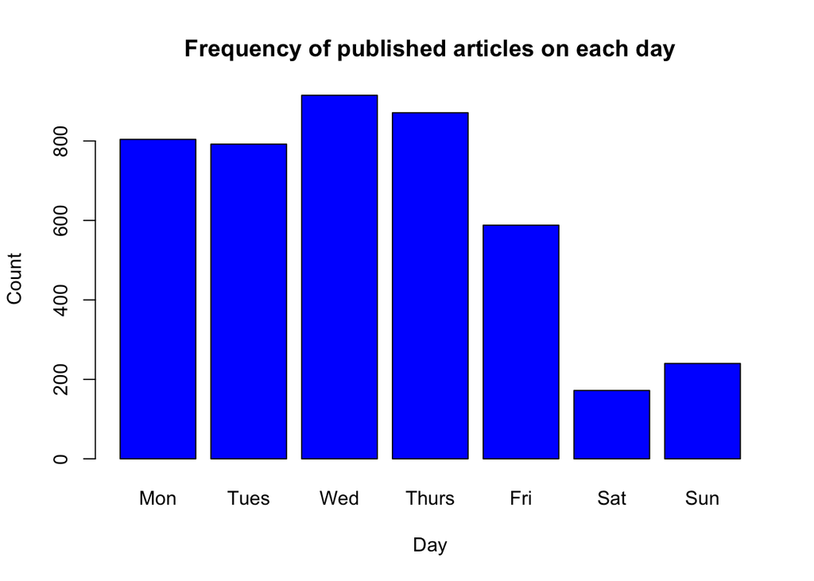

```r
barplot(days, main = "Frequency of published articles on each day", ylab = "Count", xlab = "Day",names.arg = c("Mon", "Tues", "Wed", "Thurs", "Fri", "Sat", "Sun"), col = "blue")
```

We can also look at different attributes that the articles have such as number of images and number of number of videos. We can explore if there are more shares with more images or videos.

```r
dataTrain %>%
  group_by(num_imgs, num_videos) %>%
  summarise(mean = mean(shares), sd = sd(shares))
```

```
## # A tibble: 133 × 4
## # Groups:   num_imgs [38]
##    num_imgs num_videos   mean     sd
##       <dbl>      <dbl>  <dbl>  <dbl>
##  1        0          0  2025.  6895.
##  2        0          1  4348. 13283.
##  3        0          2 14349. 42253.
##  4        0          3  1773.   763.
##  5        0          4  1786    773.
##  6        0          5  1503.   600.
##  7        0          6  3500     NA
##  8        0          7  1600     NA
##  9        0          8   902     NA
## 10        0         10  1478    738.
## # ℹ 123 more rows
```

Let’s visualize this. First for number of images:

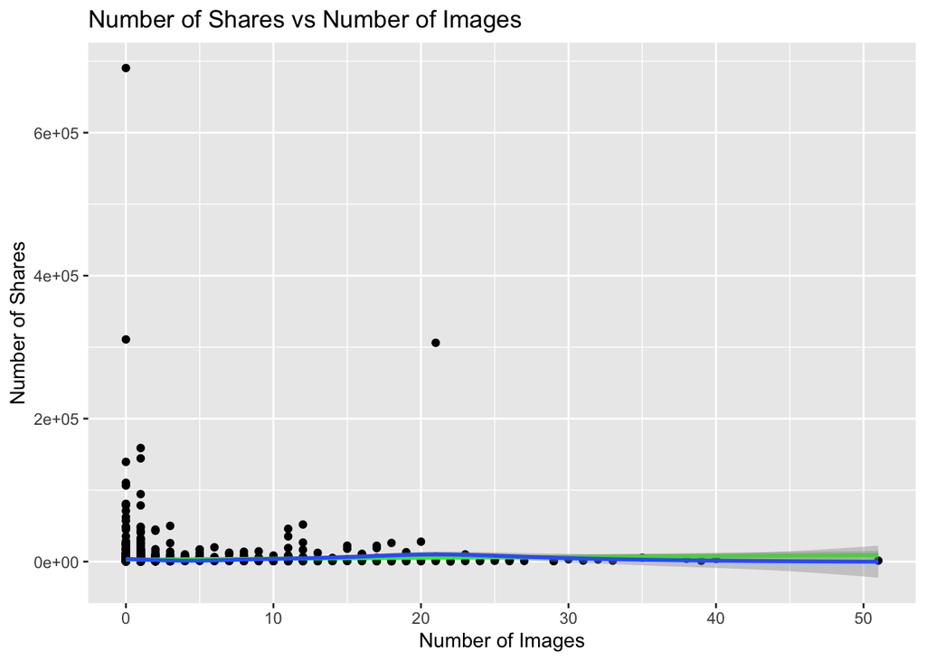

```r
ggplot(dataTrain, aes(x = num_imgs, y = shares)) +
  geom_point() +
    geom_smooth(method = "lm", col = "green") +
  geom_smooth() +
   labs(title = "Number of Shares vs Number of Images", x = "Number of Images", y = "Number of Shares")
```

From the above plot if the trend shows a positive linear line, as number of images included in the article increases as does the number of shares. If it shows a negative linear line, the number of shares decreases with the addition of images. If no trend is shown, the number of images included has no impact on overall shares.

For number of videos:

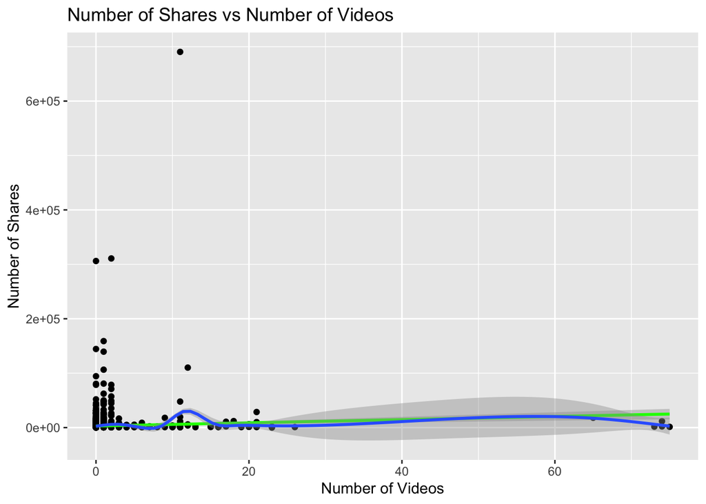

```r
ggplot(dataTrain, aes(x = num_videos, y = shares)) +
  geom_point() +
  geom_smooth(method = "lm", col = "green") +
  geom_smooth() +
  labs(title = "Number of Shares vs Number of Videos", x = "Number of Videos", y = "Number of Shares")
```

Similar to above, from the above plot if the trend shows a positive linear line, as number of videos included in the article increases as does the number of shares. If it shows a negative linear line, the number of shares decreases with the addition of videos If no trend is shown, the number of videos included has no impact on overall shares.

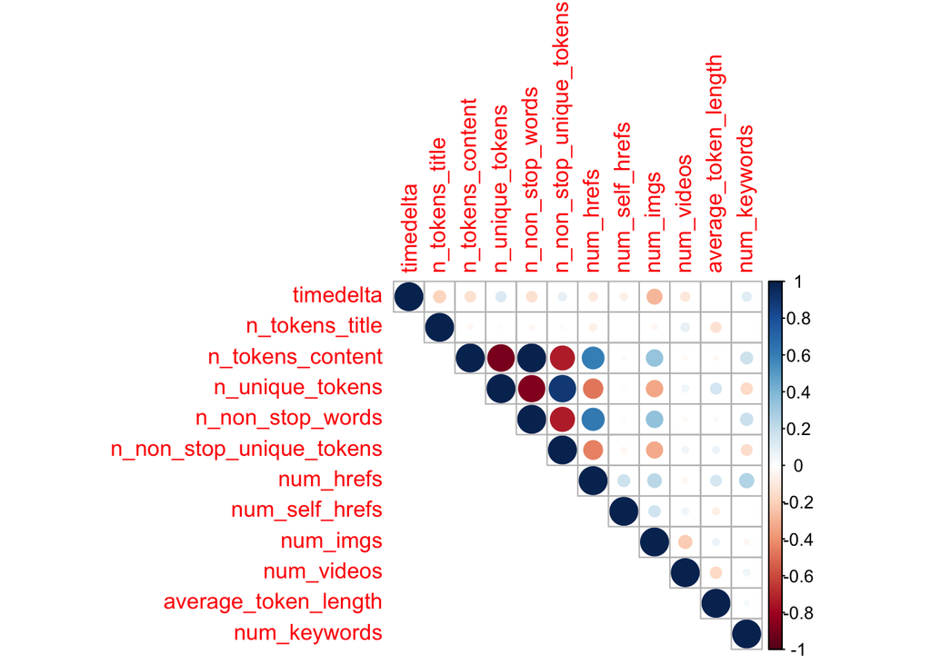

```r
correlation <- cor(select(dataTrain, 2:13), method = "spearman")
corrplot(correlation, type = "upper", tl.pos = "lt")
```

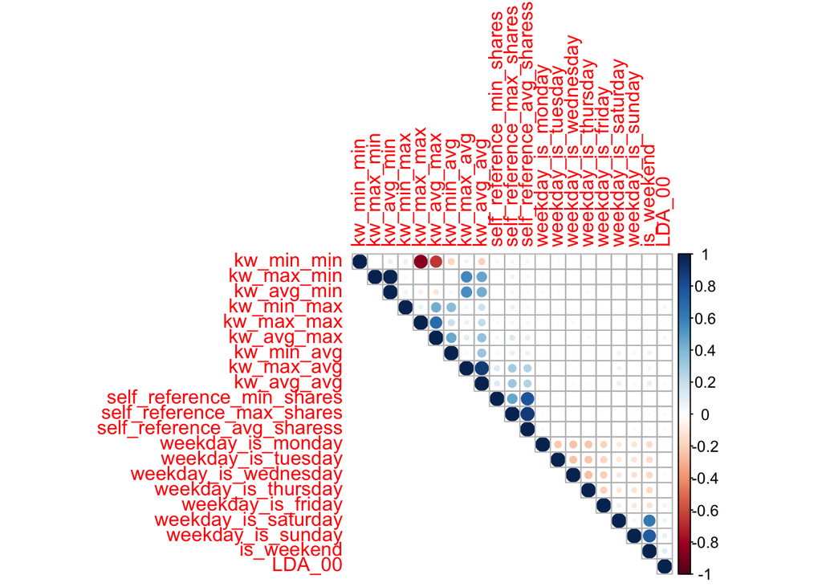

```r
correlation2 <-cor(select(dataTrain, 20:40))
corrplot(correlation2, type = "upper", tl.pos = "lt")
```

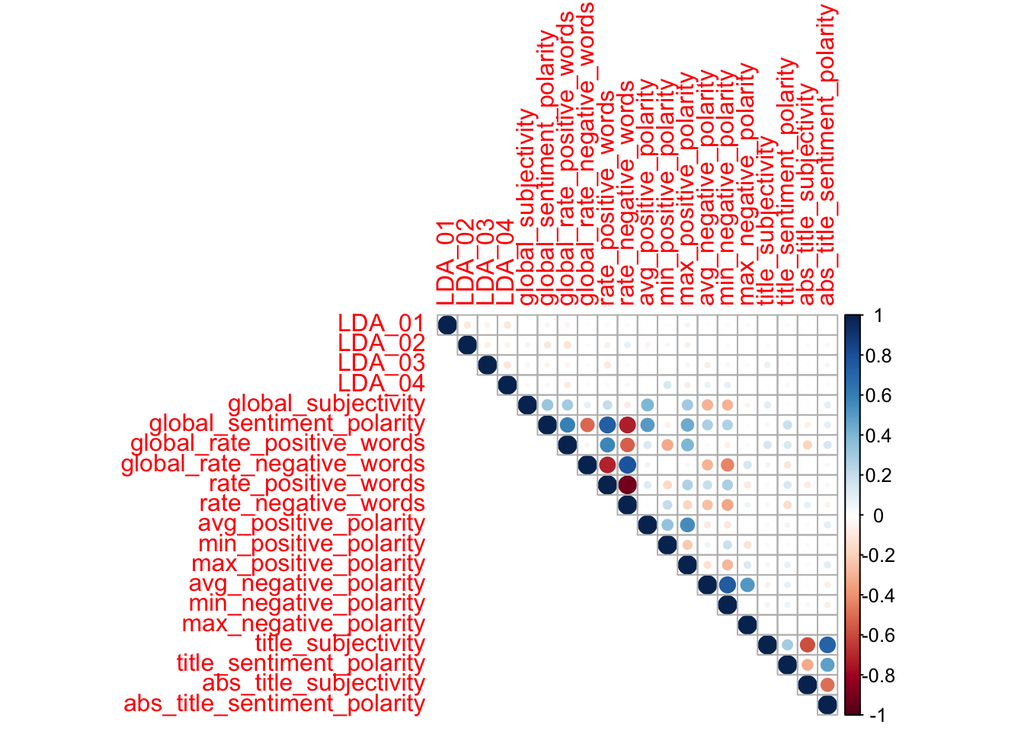

```r
correlation3 <-cor(select(dataTrain, 41:60))
corrplot(correlation3, type = "upper", tl.pos = "lt")
```

*As you will automate this same analysis across other data, you can’t describe the trends you see in the graph (unless you want to try to automate that!). You should describe what to look for in the summary statistics/plots to help the reader understand the summary or graph.*

# Modeling

**RINA: linear regression & boosted tree model & explanation of the ensemble model you are using**

```r
dataTrain <- dataTrain %>% select(-starts_with("data_channel"),-url, -channel)
dataTest <- dataTest %>% select(-starts_with("data_channel"),-url, -channel)
preprocess <- preProcess(dataTrain, method = c("center", "scale"))
trainPreprocessed <- predict(preprocess, dataTrain)
testPreprocessed <- predict(preprocess, dataTest)
```

```r
lmFit1<- train(shares ~ ., data = dataTrain, method = "lm",preProcess=c("center","scale"),
trControl = trainControl(method = "cv", number = 5))
summary(lmFit1)
```

```
##
## Call:
## lm(formula = .outcome ~ ., data = dat)
##
## Residuals:
##    Min     1Q Median     3Q    Max
## -37272  -2204   -868    520 676096
##
## Coefficients: (3 not defined because of singularities)
##                               Estimate Std. Error t value Pr(>|t|)
## (Intercept)                   3037.073    208.788  14.546  < 2e-16 ***
## timedelta                      389.653    304.211   1.281 0.200310
## n_tokens_title                 335.907    222.299   1.511 0.130846
## n_tokens_content               413.569    433.077   0.955 0.339653
## n_unique_tokens                258.518    767.661   0.337 0.736314
## n_non_stop_words              -199.470    855.969  -0.233 0.815746
## n_non_stop_unique_tokens       556.169    621.942   0.894 0.371241
## num_hrefs                      237.683    297.702   0.798 0.424687
## num_self_hrefs                 331.286    239.666   1.382 0.166956
## num_imgs                       234.830    231.450   1.015 0.310350
## num_videos                     516.349    230.534   2.240 0.025155 *
## average_token_length          -258.143    336.490  -0.767 0.443026
## num_keywords                   102.735    281.722   0.365 0.715377
## kw_min_min                     160.044    419.679   0.381 0.702963
## kw_max_min                   -1118.672   1617.901  -0.691 0.489330
## kw_avg_min                    1359.658   1627.544   0.835 0.403536
## kw_min_max                    -252.421    255.829  -0.987 0.323856
## kw_max_max                     169.352    456.454   0.371 0.710644
## kw_avg_max                    -471.632    489.868  -0.963 0.335715
## kw_min_avg                      55.977    300.357   0.186 0.852164
## kw_max_avg                   -2481.351    665.959  -3.726 0.000197 ***
## kw_avg_avg                    3397.744    715.315   4.750  2.1e-06 ***
## self_reference_min_shares     -661.504    567.247  -1.166 0.243612
## self_reference_max_shares    -1492.155    788.232  -1.893 0.058419 .
## self_reference_avg_sharess    2158.015   1101.976   1.958 0.050257 .
## weekday_is_monday              310.814    402.907   0.771 0.440494
## weekday_is_tuesday             106.185    402.969   0.264 0.792173
## weekday_is_wednesday            69.128    418.911   0.165 0.868937
## weekday_is_thursday             34.253    412.739   0.083 0.933863
## weekday_is_friday             -207.195    371.349  -0.558 0.576906
```

[output cut: 15 more lines]

```
## min_positive_polarity         -210.473    290.176  -0.725 0.468289
## max_positive_polarity           85.020    338.042   0.252 0.801434
## avg_negative_polarity          908.748    555.626   1.636 0.102009
## min_negative_polarity         -980.726    493.567  -1.987 0.046984 *
## max_negative_polarity         -557.279    354.528  -1.572 0.116049
## title_subjectivity             145.098    334.238   0.434 0.664225
## title_sentiment_polarity       316.474    250.428   1.264 0.206394
## abs_title_subjectivity         498.599    273.274   1.825 0.068140 .
## abs_title_sentiment_polarity    42.989    335.934   0.128 0.898179
## ---
## Signif. codes:  0 '***' 0.001 '**' 0.01 '*' 0.05 '.' 0.1 ' ' 1
##
## Residual standard error: 13820 on 4331 degrees of freedom
## Multiple R-squared:  0.03107,    Adjusted R-squared:  0.01988
## F-statistic: 2.777 on 50 and 4331 DF,  p-value: 4.299e-10
```

```r
lmFit1Pred <- predict(lmFit1, newdata = testPreprocessed)
lm1 <- postResample(lmFit1Pred, testPreprocessed$shares)
boosted_tree_model$bestTune
```

[output not shown]

```
##   n.trees interaction.depth shrinkage n.minobsinnode
## 1      25                 1       0.1             10
```

```r
boosted_tree_model$results
```

```
##    shrinkage interaction.depth n.minobsinnode n.trees      RMSE    Rsquared
## 1        0.1                 1             10      25 0.8948765 0.004218042
## 6        0.1                 2             10      25 0.9045878 0.008922156
## 11       0.1                 3             10      25 0.9082764 0.008024457
## 16       0.1                 4             10      25 0.9058633 0.008441066
## 2        0.1                 1             10      50 0.9023983 0.006096800
## 7        0.1                 2             10      50 0.9170660 0.007758889
## 12       0.1                 3             10      50 0.9179600 0.008428223
## 17       0.1                 4             10      50 0.9212196 0.007273349
## 3        0.1                 1             10     100 0.9059738 0.008578965
## 8        0.1                 2             10     100 0.9231202 0.006455856
## 13       0.1                 3             10     100 0.9281997 0.008258323
## 18       0.1                 4             10     100 0.9421169 0.006775444
## 4        0.1                 1             10     150 0.9231801 0.008676293
## 9        0.1                 2             10     150 0.9304581 0.007224345
```

[output cut: 27 more lines]

```r
boosted_tree_predictions <- predict(boosted_tree_model, newdata = testPreprocessed)

boosted_tree <- postResample(boosted_tree_predictions, testPreprocessed$shares)
boosted_tree
```

```
##        RMSE    Rsquared         MAE
## 1.241401695 0.004146853 0.200746792
```

**JESS: linear regression & random forest model & explanation of the idea of a linear regression model & explanation of the ensemble model you are using**

```r
lmFit2 <- train(shares ~ .^2, data = dataTrain, method = "lm",preProcess=c("center","scale"),
trControl = trainControl(method = "cv", number = 5))

summary(lmFit2)
```

```
##
## Call:
## lm(formula = .outcome ~ ., data = dat)
##
## Residuals:
##    Min     1Q Median     3Q    Max
## -40951  -3587    -75   3155 160377
##
## Coefficients: (250 not defined because of singularities)
##                                                             Estimate Std. Error
## (Intercept)                                                3.037e+03  1.464e+02
## timedelta                                                  6.003e+09  1.473e+10
## n_tokens_title                                            -7.015e+08  1.721e+09
## n_tokens_content                                           1.754e+04  1.873e+04
## n_unique_tokens                                           -6.706e+03  2.162e+04
## n_non_stop_words                                           1.689e+09  4.146e+09
## n_non_stop_unique_tokens                                   1.013e+04  1.739e+04
## num_hrefs                                                 -5.447e+03  1.190e+04
## num_self_hrefs                                             3.056e+03  8.904e+03
## num_imgs                                                   4.200e+07  1.041e+08
## num_videos                                                 1.507e+11  3.699e+11
## average_token_length                                       7.103e+03  7.645e+03
## num_keywords                                              -2.210e+09  5.423e+09
## kw_min_min                                                 4.569e+04  1.846e+04
## kw_max_min                                                -7.876e+10  1.933e+11
## kw_avg_min                                                 5.460e+10  1.340e+11
## kw_min_max                                                -4.185e+09  1.027e+10
## kw_max_max                                                 3.924e+04  1.480e+04
## kw_avg_max                                                -3.703e+09  9.087e+09
## kw_min_avg                                                -1.819e+08  4.464e+08
## kw_max_avg                                                -4.156e+09  1.020e+10
## kw_avg_avg                                                 5.091e+09  1.249e+10
## self_reference_min_shares                                 -9.733e+04  8.270e+04
## self_reference_max_shares                                 -1.250e+05  9.712e+04
## self_reference_avg_sharess                                 1.527e+05  1.540e+05
## weekday_is_monday                                         -1.385e+09  3.399e+09
## weekday_is_tuesday                                        -4.663e+08  1.144e+09
## weekday_is_wednesday                                      -2.829e+03  1.549e+04
## weekday_is_thursday                                       -1.209e+04  1.525e+04
## weekday_is_friday                                         -5.626e+03  1.359e+04
```

[output cut: 2826 more lines]

```
## `max_negative_polarity:title_sentiment_polarity`           -1.846 0.064936 .
## `max_negative_polarity:abs_title_subjectivity`             -3.091 0.002009 **
## `max_negative_polarity:abs_title_sentiment_polarity`        1.090 0.275732
## `title_subjectivity:title_sentiment_polarity`              -0.097 0.922507
## `title_subjectivity:abs_title_subjectivity`                 1.121 0.262406
## `title_subjectivity:abs_title_sentiment_polarity`           1.179 0.238638
## `title_sentiment_polarity:abs_title_subjectivity`          -0.562 0.573912
## `title_sentiment_polarity:abs_title_sentiment_polarity`    -0.952 0.341068
## `abs_title_subjectivity:abs_title_sentiment_polarity`       0.365 0.715034
## ---
## Signif. codes:  0 '***' 0.001 '**' 0.01 '*' 0.05 '.' 0.1 ' ' 1
##
## Residual standard error: 9689 on 3200 degrees of freedom
## Multiple R-squared:  0.6482, Adjusted R-squared:  0.5184
## F-statistic: 4.992 on 1181 and 3200 DF,  p-value: < 2.2e-16
```

```r
lmFit2Pred <- predict(lmFit2, newdata = dataTest)
lm2 <- postResample(lmFit2Pred, dataTest$shares)
```

```r
library(randomForest)
#using cross validation
#only used 1:10 to keep run time low
rfFit <- train(shares ~ ., data = trainPreprocessed, method = "rf",
               trControl = trainControl(method = "cv", number = 5),
               tuneGrid = data.frame(mtry = 1:10))
rfFit$results
rfFit$bestTune
rfPred <- predict(rfFit, newdata = testPreprocessed)
rf <- postResample(rfPred, testPreprocessed$shares)
```

[output not shown]

*You’ll need to split the data into a training (70% of the data) and test set (30% of the data). Use set.seed() to make things reproducible.*

*The goal is to create models for predicting the number of shares in some way.*

*Each group member should contribute a linear regression model and an ensemble tree-based model. As we are automating things, describing the chosen model is tough, so no need to worry about that.*

*Both models should be chosen using cross-validation.*

## Comparison

```r
df <- data.frame(linear1 = lm1, linear2 = lm2, boostedTree = boosted_tree)
dftransp <- as.data.frame(t(df))
dftransp <- dftransp %>%
  arrange(RMSE)
dftransp[1, ]
```

```
##                 RMSE    Rsquared       MAE
## boostedTree 1.241402 0.004146853 0.2007468
```

# Automation

**RINA or JESS**

*Once you’ve completed the above for a particular data channel, adapt the code so that you can use a parameter in your build process. You should be able to automatically generate an analysis report for each data_channel_is_ variable*

*You’ll end up with six total outputted documents.*